# Tugas Kelompok Analisis Regresi

Anggota kelompok 9:  
Deden Ahmad Rabani (G1401221016)  
Nabil Bintang Prayoga (G1401221017)  
Fathiyya Mufida (G1401220931)

# MEMBACA DATA CSV

```r
library(readxl)
data <- read.csv("C:/Users/nbint/Downloads/2019.csv", sep=",")
head(data)
```

```
##   Overall.rank Country.or.region Score GDP.per.capita Social.support
## 1            1           Finland 7.769          1.340          1.587
## 2            2           Denmark 7.600          1.383          1.573
## 3            3            Norway 7.554          1.488          1.582
## 4            4           Iceland 7.494          1.380          1.624
## 5            5       Netherlands 7.488          1.396          1.522
## 6            6       Switzerland 7.480          1.452          1.526
##   Healthy.life.expectancy Freedom.to.make.life.choices Generosity
## 1                   0.986                        0.596      0.153
## 2                   0.996                        0.592      0.252
## 3                   1.028                        0.603      0.271
## 4                   1.026                        0.591      0.354
## 5                   0.999                        0.557      0.322
## 6                   1.052                        0.572      0.263
##   Perceptions.of.corruption
## 1                     0.393
## 2                     0.410
## 3                     0.341
## 4                     0.118
## 5                     0.298
## 6                     0.343
```

## Pendefinisian Variabel

```r
Country<-data$Country.or.region
Y<-data$Score
X1<-data$GDP.per.capita
X2<-data$Social.support
X3<-data$Healthy.life.expectancy
X4<-data$Freedom.to.make.life.choices
X5<-data$Generosity
X6<-data$Perceptions.of.corruption
```

## Data dengan Nama Variabel Baru

```r
data<-data.frame(cbind(Y,X1,X2,X3,X4,X5,X6))
head(data)
```

```
##       Y    X1    X2    X3    X4    X5    X6
## 1 7.769 1.340 1.587 0.986 0.596 0.153 0.393
## 2 7.600 1.383 1.573 0.996 0.592 0.252 0.410
## 3 7.554 1.488 1.582 1.028 0.603 0.271 0.341
## 4 7.494 1.380 1.624 1.026 0.591 0.354 0.118
## 5 7.488 1.396 1.522 0.999 0.557 0.322 0.298
## 6 7.480 1.452 1.526 1.052 0.572 0.263 0.343
```

## Hitung Baris dan Kolom

```r
(n<-nrow(data))
```

```
## [1] 156
```

```r
(p<-ncol(data))
```

```
## [1] 7
```

Pada analisis regresi linier sederhana ini, data yang digunakan diambil dari situs kaggle.com/dataset berupa penelitian terkait tingkat kebahagiaan di setiap negara atau wilayah pada tahun 2019. Skor tersebut didasarkan pada jawaban dari pertanyaan yang diajukan dalam jajak pendapat yang dikenal sebagai tangga cantril, meminta responden untuk memikirkan prioritas dari skala 0 sampai 10. Skor berasal dari sampel yang representatif secara nasional dari 156 negara atau wilayah.

Variabel Y pada data ini adalah skor tingkat kebahagiaan di setiap negara dan dari 6 variabel X yang tersedia, dipilih X1 yaitu GDP per kapita sebagai variabel yang digunakan pada analisis ini. Berdasarkan penelitian sebelumnya, peningkatan pendapatan dapat meningkatkan tingkat kebahagiaan. Implikasi dari temuan ini adalah tingkat kebahagiaan dari masyarakat suatu wilayah dapat didorong dengan peningkatan pendapatan, karena pendapatan merupakan faktor penting untuk mendapatkan dan membuka akses pangan, kesehatan, dan layanan umum, sehingga meningkatkan kualitas kehidupan yang lebih baik yang berimplikasi kebahagiaan pun meningkat (Fajar dan Eko, 2022). Oleh karenanya, kami ingin menganalisis pengaruh GDP per kapita terhadap tingkat kebahagiaan di suatu negara atau wilayah berdasarkan data yang sudah ada.

# EKSPLORASI DATA

Scatter plot di bawah ini menggambarkan hubungan antara X1 (GDP per kapita) dan Y (skor tingkat kebahagiaan) yang linier positif. Semakin tinggi GDP per kapita, maka skor tingkat kebahagiaan juga semakin tinggi.

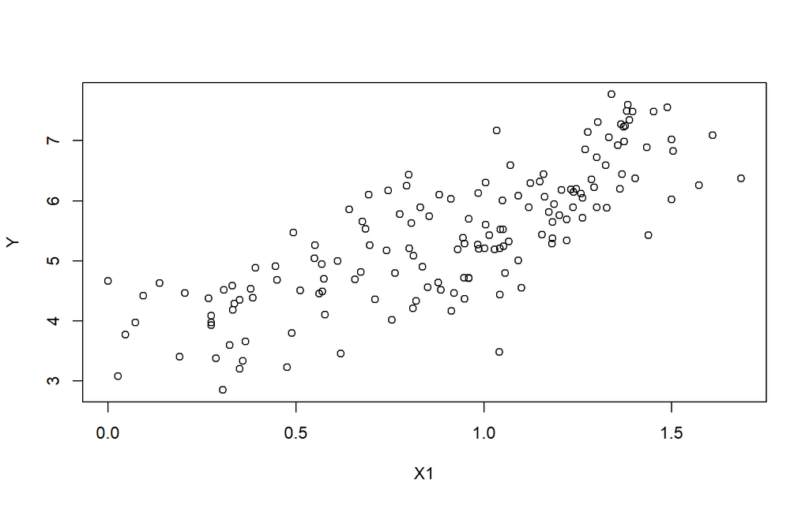

```r
plot(X1,Y)
```

## Rangkuman Statistik Variabel Y

```r
summary(Y)
```

```
##    Min. 1st Qu.  Median    Mean 3rd Qu.    Max.
##   2.853   4.545   5.380   5.407   6.184   7.769
```

## Rangkuman Statistik Variabel X1

```r
summary(X1)
```

```
##    Min. 1st Qu.  Median    Mean 3rd Qu.    Max.
##  0.0000  0.6028  0.9600  0.9051  1.2325  1.6840
```

# ANALISIS DATA DENGAN FUNGSI LM

```r
model<-lm(Y~X1,data<-data)
summary(model)
```

```
##
## Call:
## lm(formula = Y ~ X1, data = data <- data)
##
## Residuals:
##      Min       1Q   Median       3Q      Max
## -2.22044 -0.48361  0.00828  0.48433  1.47409
##
## Coefficients:
##             Estimate Std. Error t value Pr(>|t|)
## (Intercept)   3.3993     0.1353   25.12   <2e-16 ***
## X1            2.2181     0.1369   16.20   <2e-16 ***
## ---
## Signif. codes:  0 '***' 0.001 '**' 0.01 '*' 0.05 '.' 0.1 ' ' 1
##
## Residual standard error: 0.679 on 154 degrees of freedom
## Multiple R-squared:  0.6303, Adjusted R-squared:  0.6278
## F-statistic: 262.5 on 1 and 154 DF,  p-value: < 2.2e-16
```

```r
(anova.model<-anova(model))
```

```
## Analysis of Variance Table
##
## Response: Y
##            Df  Sum Sq Mean Sq F value    Pr(>F)
## X1          1 121.040 121.040   262.5 < 2.2e-16 ***
## Residuals 154  71.011   0.461
## ---
## Signif. codes:  0 '***' 0.001 '**' 0.01 '*' 0.05 '.' 0.1 ' ' 1
```

## Ukuran Kebaikan Model

```r
(Koef_det<-1-(anova.model$`Sum Sq`[2]/sum(anova.model$`Sum Sq`)))
```

```
## [1] 0.63025
```

Koefisien determinasi menunjukkan angka sebesar 0.63025 atau 63.025%, artinya bahwa variasi skor tingkat kebahagiaan mampu dijelaskan oleh variasi GDP per kapita sebesar 63.025%. Sisanya sebesar 36.975% variasi skor tingkat kebahagiaan dijelaskan oleh faktor atau variabel lain di luar model.

# KERAGAMAN DUGAAN PARAMETER

```r
qt(0.025,df=n-2,lower.tail=FALSE)
```

```
## [1] 1.975488
```

## Dugaan parameter $\beta_0$

```r
(b0<-model$coefficients[[1]])
```

```
## [1] 3.399345
```

```r
(se_b0<-sqrt(anova.model$`Mean Sq`[2]*(1/n+mean(X1)^2/sum((X1-mean(X1))^2))))
```

```
## [1] 0.1353233
```

```r
(t_b0 <- b0/se_b0)
```

```
## [1] 25.12018
```

### Hipotesis Uji $\beta_0$

$H_0:\beta_0=0$ (semua skor tingkat kebahagiaan dapat dijelaskan oleh besarnya GDP per kapita)  
$H_0:\beta_0≠0$ (ada skor tingkat kebahagiaan yang tidak dapat dijelaskan oleh besarnya GDP per kapita)  
Karena t = 25.12 > $t(0.05/2;156-2)$ = 1.975 maka tolak $H_0$, sehingga cukup bukti untuk menyatakan bahwa ada skor tingkat kebahagiaan yang tidak dapat dijelaskan oleh besarnya GDP per kapita pada taraf nyata 5%.

## Dugaan Parameter $\beta_1$

```r
(b1<-model$coefficients[[2]])
```

```
## [1] 2.218148
```

```r
(se_b1<-sqrt(anova.model$`Mean Sq`[2]/sum((X1-mean(X1))^2)))
```

```
## [1] 0.1369077
```

```r
(t_b1<-b1/se_b1)
```

```
## [1] 16.20178
```

### Hipotesis Uji $\beta_1$

$H_0:\beta_1=0$ (tidak ada hubungan linier antara GDP per kapita dengan skor tingkat kebahagiaan)  
$H_0:\beta_1≠0$ (ada hubungan linier antara GDP per kapita dengan skor tingkat kebahagiaan)  
Karena t = 16.20 > $t(0.05/2;156-2)$ = 1.975 maka tolak $H_0$ yang menunjukkan adanya hubungan linier antara GDP per kapita dengan skor tingkat kebahagiaan. Sehingga cukup bukti untuk menyatakan bahwa nilai GDP per kapita memngaruhi besarnya skor tingkat kebahagiaan suatu negata atau wilayah pada taraf nyata 5%.

# SELANG KEPERCAYAAN PARAMETER

## Selang kepercayaan $\beta_0$

```r
(sk.b0<-c(b0-abs(qt(0.025, df=n-2))*se_b0, b0 + abs(qt(0.025, df=n-2))*se_b0))
```

```
## [1] 3.132016 3.666675
```

## Selang kepercayaan $\beta_1$

```r
(sk.b1<-c(b1-abs(qt(0.025, df=n-2))*se_b1, b1 + abs(qt(0.025, df=n-2))*se_b1))
```

```
## [1] 1.947689 2.488607
```

Jadi, pada taraf nyata 5%, diyakini bahwa dugaan parameter $\beta_1$ berada pada selang 1.947689 sampai 2.488607

# SELANG KEPERCAYAAN RATAAN (NILAI HARAPAN) AMATAN

```r
amatan.diduga <- data.frame(X1=1.245)
predict(model, amatan.diduga, interval = "confidence")
```

```
##        fit      lwr      upr
## 1 6.160939 6.019575 6.302304
```

Misal ingin menduga nilai rataan (harapan) amatan ketika nilai GDP per kapita negara tertentu adalah 1.245, maka diperoleh dugaan rataan skor tingkat kebahagiaan sebesar 6.160939  
Selain itu diindikasikan juga bahwa dalam taraf kepercayaan 95%, diyakini bahwa nilai dugaan rataan skor tingkat kebahagiaan ketika nilai GDP per kapita adalah 1.245 berada dalam selang 6.019575 hingga 6.302304

# SELANG KEPERCAYAAN INDIVIDU AMATAN

```r
predict(model, amatan.diduga, interval = "prediction")
```

```
##        fit      lwr      upr
## 1 6.160939 4.812057 7.509822
```

Misal ingin menduga nilai individu amatan ketika nilai GDP per kapita negara tertentu adalah 1.245, maka diperoleh dugaan skor tingkat kebahagiaan sebesar 6.160939  
Selain itu diindikasikan juga bahwa dalam taraf kepercayaan 95%, diyakini bahwa nilai amatan individu skor tingkat kebahagiaan ketika nilai GDP per kapita adalah 1.245 berada dalam selang 4.812057 hingga 7.509822